# Practical Machine Learning Prediction Assignment

26 February 2016

# Practical Machine Learning Prediction Assignment

## Background

Using data from Human Activity Recognition devices we are required to undertake data analysis on the data at http://groupware.les.inf.puc-rio.br/har.

The goal of the excercise is to predict the manner in which exercise was conducted either correctly being classe “A” or the incorrect options being classe’s “B through E”.

```r
suppressMessages(library("dplyr"))
require(dplyr)
suppressMessages(library("tree"))
require(tree)
suppressMessages(library("caret"))
require(caret)
require(ggplot2)
suppressMessages(library("rattle"))
require(rattle)
set.seed(5436)
```

## Getting the data

```r
if(!getwd()== "C:/R/pml"){
        dir.create("C:/R/pml");
        setwd("C:/R/pml")
        download.file("https://d396qusza40orc.cloudfront.net/predmachlearn/pml-training.csv", "pml_train.csv")
download.file("https://d396qusza40orc.cloudfront.net/predmachlearn/pml-testing.csv", "pml_test.csv")
                        }
```

## Cleaning the data

After undertaking an initial review of the data I remove factor variables and non numeric data from the initial view of the training data set being columns 1,2,5,6,7.

I then removed variables with:  
1. zero variance,  
2. columnns with NA values, and  
3. highly correlated data.

```r
options(warn = -1)
# Load test data
train <- read.csv("pml_train.csv", na.strings = c("NA","","#DIV/0"))

# subset the train data to undertake validation prior to using the test data
inTrain = createDataPartition(train$classe  , p = 3/4)[[1]]

training <- train[inTrain,]
vldtn <- train[-inTrain,]

test <- read.csv("pml_test.csv", na.strings = c("NA","","#DIV/0"))


##  Cleaning the data
#Initially I retrieved only the information pertaining to accelerometers on the belt, forearm, arm, and dumbell.  This was a dumb move.
# subs <- grep("class|belt|forearm|arm|dumbell ", names(train), value = TRUE)
#training <- training[,subs]
training <- training[,-c(1,2,5,6,7)]

# find and remove values with zero variance
        nzv <- nearZeroVar(training[,-55]+1, saveMetrics = T)
        training <- training[,nzv$zeroVar == FALSE]


# remove columns with NAs
# code at stack overflow re finding columns with missing values
        NaVal <- sapply(training, function (x) any(is.na(x) | x == ""))
        training <- training[,NaVal != T]
```

# Initial Analysis

Loading the training data into a tree from the tree package we are able to look at a plot of the data to see what trends may be evident. We can see that there are a number of leaves from the tree but can’t see what may be causing them that at this point.

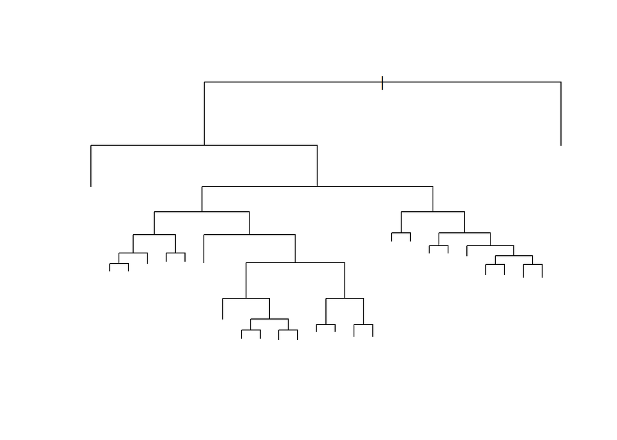

```r
init_tree <- tree(classe~., data = na.omit(training))
 plot(init_tree)
```

```r
summary(init_tree)
```

```
##
## Classification tree:
## tree(formula = classe ~ ., data = na.omit(training))
## Variables actually used in tree construction:
##  [1] "roll_belt"            "pitch_forearm"        "roll_forearm"
##  [4] "raw_timestamp_part_1" "magnet_forearm_y"     "accel_dumbbell_x"
##  [7] "yaw_belt"             "magnet_dumbbell_y"    "accel_forearm_x"
## [10] "magnet_arm_y"         "magnet_belt_z"
## Number of terminal nodes:  26
## Residual mean deviance:  0.9956 = 14630 / 14690
## Misclassification error rate: 0.172 = 2532 / 14718
```

```r
# find and remove values with high correlation
ncl <- ncol(training)
t <- findCorrelation(training[,-51], cutoff = 0.9, exact = F)
training <- training[,-t]
```

## Model Fitting

I’ve chosen two model methods to fit over the data, being rpart to fit a regression model and random forest. The train control option was selected as the initial random forest method was going over time.

```r
trCont <- trainControl(method = "cv", number = 10 )
modFit <- train(classe ~., data = training, method ="rpart", trControl = trCont )
modFit2 <- train(classe ~., data = training, method ="rf", trControl = trCont)
```

```r
summary(modFit$results)
```

```
##        cp             Accuracy          Kappa           AccuracySD
##  Min.   :0.01472   Min.   :0.3180   Min.   :0.05203   Min.   :0.009695
##  1st Qu.:0.03203   1st Qu.:0.3359   1st Qu.:0.08032   1st Qu.:0.014005
##  Median :0.04934   Median :0.3538   Median :0.10862   Median :0.018315
##  Mean   :0.04154   Mean   :0.3696   Mean   :0.13904   Mean   :0.024558
##  3rd Qu.:0.05495   3rd Qu.:0.3954   3rd Qu.:0.18254   3rd Qu.:0.031989
##  Max.   :0.06057   Max.   :0.4370   Max.   :0.25646   Max.   :0.045664
##     KappaSD
##  Min.   :0.02679
##  1st Qu.:0.02755
##  Median :0.02831
##  Mean   :0.04270
##  3rd Qu.:0.05065
##  Max.   :0.07299
```

[figure not shown]

```r
fancyRpartPlot(modFit$finalModel)
```

```r
summary(modFit2$results)
```

```
##       mtry           Accuracy          Kappa          AccuracySD
##  Min.   : 2.000   Min.   :0.8755   Min.   :0.8422   Min.   :0.005385
##  1st Qu.: 4.500   1st Qu.:0.8844   1st Qu.:0.8535   1st Qu.:0.006318
##  Median : 7.000   Median :0.8933   Median :0.8648   Median :0.007252
##  Mean   : 7.333   Mean   :0.8912   Mean   :0.8621   Mean   :0.007110
##  3rd Qu.:10.000   3rd Qu.:0.8991   3rd Qu.:0.8720   3rd Qu.:0.007972
##  Max.   :13.000   Max.   :0.9048   Max.   :0.8793   Max.   :0.008692
##     KappaSD
##  Min.   :0.006831
##  1st Qu.:0.007996
##  Median :0.009161
##  Mean   :0.009005
##  3rd Qu.:0.010092
##  Max.   :0.011024
```

The final answers for the quiz outcome can be obtained by predicting on modFit2 against the test data. I’m not showing this as that isn’t the point of this exercise.